# Assignment_4

Kevin McMorrow

5/1/2019

## QAC305 - Assignment 4

## Part 1

Load in necessary libraries and the data set

```r
library(FactoMineR)
load("cola.perceptions.rdata")
cola = as.table(as.matrix(cola.perceptions))
```

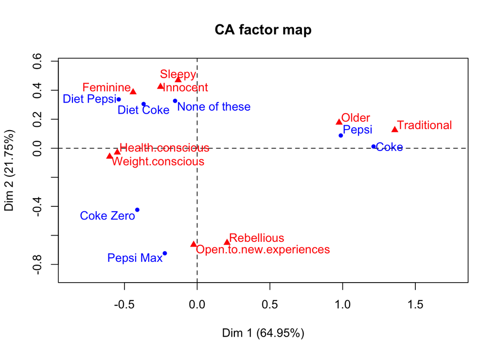

```r
fit.ca = CA(cola, graph=F)
plot(fit.ca)
```

Diet Pepsi and Diet Coke are a similar pair. Pepsi and Coke are similar as well.

“Innocent”, “Feminine”, and “Sleepy” are all similar adjectives with respect to their use in describing the soda brands. “Health Conscious” and “Weight Conscious” are as well, and so are “Older”, and “Traditional”. “Open to New Experiences” and “Rebllious” are relatively similar.

## Part 2

```r
load("warriors.rdata")
library(dbscan)
```

```r
warriors_sc <- scale(warriors[-1])
warriors_lof <- lof(warriors_sc, k=5)
warriors$score_lof <- warriors_lof
rownum <- which.max(warriors$score_lof)

warriors[rownum, ]
```

```
##                Age G GS MP FG FGA FGP 3P 3PA 2P 2PA 2PP eFGP FT FTA FTP
## Dewayne Dedmon  24 4  0  6  0   1   0  0   0  0   1   0    0  1   2 0.5
##                ORB DRB TRB AST STL BLK TOV PF PTS score_lof
## Dewayne Dedmon   0   0   0   0   0   0   0  1   1  2.380203
```

```r
warriors_sc[rownum, ]
```

```
##          G         GS         MP         FG        FGA        FGP
## -1.5583882 -0.7170746 -1.0701143 -0.8805997 -0.9007078 -3.0510812
##         3P        3PA         2P        2PA        2PP       eFGP
## -0.5644574 -0.6253091 -0.8989512 -0.9170204 -3.2632666 -3.2123303
##         FT        FTA        FTP        ORB        DRB        TRB
## -0.8139989 -0.9026731 -1.0496872 -0.8534522 -0.9868703 -0.9664370
##        AST        STL        BLK        TOV         PF        PTS
## -0.6683862 -0.8757143 -0.7267425 -0.9301350 -1.1215649 -0.8589821
```

Dewayne Dedmon is the most unusual player in the dataset.

At a quick glance it seems like his shooting rates for 2-pointers and field-goals/effective field-goals is abysmall. In actuality, he hasn’t had much of a chance to actually play, so his numbers are heavily skewed. He has only played a total of 6 minutes, which explains why he would be an outlier in the dataset.